# Lab 7

Author

Sarah Jacobson

# Lab 7: Heart Attack

```python
import pandas as pd
import numpy as np
from sklearn.pipeline import Pipeline
from sklearn.preprocessing import StandardScaler, OneHotEncoder, PolynomialFeatures, label_binarize, FunctionTransformer
from sklearn.linear_model import LinearRegression, LogisticRegression
from sklearn.model_selection import train_test_split, GridSearchCV
from sklearn.metrics import r2_score, mean_squared_error, cohen_kappa_score
from sklearn.pipeline import Pipeline
from sklearn.neighbors import KNeighborsRegressor, KNeighborsClassifier
from sklearn.tree import DecisionTreeRegressor, DecisionTreeClassifier
from sklearn.compose import make_column_selector, make_column_transformer, ColumnTransformer
from sklearn.model_selection import cross_val_score, cross_val_predict
from sklearn.metrics import confusion_matrix, ConfusionMatrixDisplay, accuracy_score, precision_score, recall_score, f1_score, roc_auc_score, classification_report, roc_curve, auc
import matplotlib.pyplot as plt

df = pd.read_csv("https://www.dropbox.com/s/aohbr6yb9ifmc8w/heart_attack.csv?dl=1")
df = df.dropna()
df.head()
```

|  | age | sex | cp | trtbps | chol | restecg | thalach | output |
| --- | --- | --- | --- | --- | --- | --- | --- | --- |
| 0 | 63 | 1 | 3 | 145 | 233 | 0 | 150 | 1 |
| 1 | 37 | 1 | 2 | 130 | 250 | 1 | 187 | 1 |
| 2 | 56 | 1 | 1 | 120 | 236 | 1 | 178 | 1 |
| 3 | 57 | 0 | 0 | 120 | 354 | 1 | 163 | 1 |
| 4 | 57 | 1 | 0 | 140 | 192 | 1 | 148 | 1 |

```python
df.describe()
```

|  | age | sex | cp | trtbps | chol | restecg | thalach | output |
| --- | --- | --- | --- | --- | --- | --- | --- | --- |
| count | 273.000000 | 273.000000 | 273.000000 | 273.000000 | 273.000000 | 273.000000 | 273.000000 | 273.000000 |
| mean | 54.347985 | 0.673993 | 0.974359 | 132.098901 | 246.860806 | 0.538462 | 149.446886 | 0.534799 |
| std | 9.163134 | 0.469611 | 1.030456 | 17.700358 | 52.569726 | 0.528059 | 23.240707 | 0.499704 |
| min | 29.000000 | 0.000000 | 0.000000 | 94.000000 | 126.000000 | 0.000000 | 71.000000 | 0.000000 |
| 25% | 47.000000 | 0.000000 | 0.000000 | 120.000000 | 211.000000 | 0.000000 | 133.000000 | 0.000000 |
| 50% | 56.000000 | 1.000000 | 1.000000 | 130.000000 | 240.000000 | 1.000000 | 152.000000 | 1.000000 |
| 75% | 61.000000 | 1.000000 | 2.000000 | 140.000000 | 275.000000 | 1.000000 | 166.000000 | 1.000000 |
| max | 77.000000 | 1.000000 | 3.000000 | 200.000000 | 564.000000 | 2.000000 | 202.000000 | 1.000000 |

```python
sex_distribution = df['sex'].value_counts(normalize=True) * 100
print(sex_distribution)
```

```
sex
1    67.399267
0    32.600733
Name: proportion, dtype: float64
sex
1    67.399267
0    32.600733
Name: proportion, dtype: float64
```

```python
risk_distribution = df['output'].value_counts(normalize=True) * 100
print(risk_distribution)
```

```
output
1    53.479853
0    46.520147
Name: proportion, dtype: float64
output
1    53.479853
0    46.520147
Name: proportion, dtype: float64
```

## Part 1: Fitting Models

### KNN

```python
#KNN Using the entire dataset

X = df.drop("output", axis = 1)
y = df["output"]

ct = ColumnTransformer(
  [
    ("dummify",
    OneHotEncoder(sparse_output = False, handle_unknown='ignore'),
    make_column_selector(dtype_include=object)),
    ("standardize", StandardScaler(),
    make_column_selector(dtype_include=np.number))
  ],
  remainder = "passthrough"
)

final_knn_pipeline1 = Pipeline(
  [("preprocessing", ct),
  ("knn", KNeighborsClassifier(n_neighbors=22))]
)

#Tuning
degrees = {'knn__n_neighbors': [5, 10, 11, 15, 20, 22, 23]}

#Cross Validation
gscv = GridSearchCV(final_knn_pipeline1, degrees, cv = 5, scoring='roc_auc')

gscv_fitted = gscv.fit(X, y)

# Get the ROC AUC scores from the grid search results
roc_auc_scores = gscv_fitted.cv_results_['mean_test_score']

# Create DataFrame for results (mean_test_score corresponds to ROC AUC scores)
roc_auc_df = pd.DataFrame(data = {
    "n_neighbors": degrees['knn__n_neighbors'],
    "roc_auc_scores": roc_auc_scores
})

# Output the ROC AUC results
roc_auc_df
```

|  | n_neighbors | roc_auc_scores |
| --- | --- | --- |
| 0 | 5 | 0.814109 |
| 1 | 10 | 0.810824 |
| 2 | 11 | 0.816007 |
| 3 | 15 | 0.833366 |
| 4 | 20 | 0.835122 |
| 5 | 22 | 0.836443 |
| 6 | 23 | 0.833147 |

```python
#KNN with age, sex, cp of 1, thalach, and interaction terms
ct1 = ColumnTransformer(
  [
    ("dummify", OneHotEncoder(sparse_output = False, drop="first"), ["cp", "sex"]),
    ("standardize", StandardScaler(), ["age", "thalach"])
  ],

  remainder = "drop"
).set_output(transform="pandas")

ct2 = ColumnTransformer([
    ("interaction1", PolynomialFeatures(interaction_only = True, include_bias=False), ["standardize__age", "dummify__sex_1"]),
    ("interaction2", PolynomialFeatures(interaction_only = True, include_bias=False), ["standardize__age", "dummify__cp_1"]),
    ("interaction3", PolynomialFeatures(interaction_only = True, include_bias=False), ["standardize__thalach", "dummify__sex_1"])]
)

ct3 =  ColumnTransformer([
    ("keep", FunctionTransformer(None), ["interaction1__standardize__age dummify__sex_1", "interaction2__standardize__age dummify__cp_1",
    "interaction1__standardize__age", "interaction3__standardize__thalach", "interaction3__dummify__sex_1", "interaction2__dummify__cp_1",
    'interaction3__standardize__thalach dummify__sex_1'])],
    remainder = "drop"
)

knn_pipeline1 = Pipeline(
  [("preprocessing", ct1),
  ("preprocessing2", ct2),
  ("preprocessing3", ct3),
  ("knn", KNeighborsClassifier(n_neighbors=5))]
).set_output(transform="pandas")

knn1 = cross_val_score(knn_pipeline1, X, y, scoring="roc_auc", cv=5).mean()
print(knn1)

#Tuning
degrees = {'knn__n_neighbors': [5, 10, 11, 15, 20, 22, 23]}

#Cross Validation
gscv = GridSearchCV(knn_pipeline1, degrees, cv = 5, scoring='roc_auc')

gscv_fitted = gscv.fit(X, y)

# Get the ROC AUC scores from the grid search results
roc_auc_scores = gscv_fitted.cv_results_['mean_test_score']

# Create DataFrame for results (mean_test_score corresponds to ROC AUC scores)
roc_auc_df = pd.DataFrame(data = {
    "n_neighbors": degrees['knn__n_neighbors'],
    "roc_auc_scores": roc_auc_scores
})

# Output the ROC AUC results
roc_auc_df
```

```
0.7860732095490717
0.7860732095490717
```

|  | n_neighbors | roc_auc_scores |
| --- | --- | --- |
| 0 | 5 | 0.786073 |
| 1 | 10 | 0.823255 |
| 2 | 11 | 0.820390 |
| 3 | 15 | 0.820687 |
| 4 | 20 | 0.827567 |
| 5 | 22 | 0.826520 |
| 6 | 23 | 0.821928 |

```python
#KNN with just cp, sex, age, and thalach

ct1 = ColumnTransformer(
  [
    ("dummify", OneHotEncoder(sparse_output = False, drop="first"), ["cp", "sex"]),
    ("standardize", StandardScaler(), ["age", "thalach"])
  ],

  remainder = "drop"
).set_output(transform="pandas")


knn_pipeline1 = Pipeline(
  [("preprocessing", ct1),
  ("knn", KNeighborsClassifier(n_neighbors=12))]
).set_output(transform="pandas")

knn1 = cross_val_score(knn_pipeline1, X, y, scoring="roc_auc", cv=5).mean()
print(knn1)

#Tuning
degrees = {'knn__n_neighbors': [5, 10, 11, 15, 20, 22, 23]}

#Cross Validation
gscv = GridSearchCV(knn_pipeline1, degrees, cv = 5, scoring='roc_auc')

gscv_fitted = gscv.fit(X, y)

# Get the ROC AUC scores from the grid search results
roc_auc_scores = gscv_fitted.cv_results_['mean_test_score']

# Create DataFrame for results (mean_test_score corresponds to ROC AUC scores)
roc_auc_df = pd.DataFrame(data = {
    "n_neighbors": degrees['knn__n_neighbors'],
    "roc_auc_scores": roc_auc_scores
})

# Output the ROC AUC results
roc_auc_df
```

```
0.8286419098143236
0.8286419098143236
```

|  | n_neighbors | roc_auc_scores |
| --- | --- | --- |
| 0 | 5 | 0.812163 |
| 1 | 10 | 0.827217 |
| 2 | 11 | 0.826018 |
| 3 | 15 | 0.818118 |
| 4 | 20 | 0.822134 |
| 5 | 22 | 0.828820 |
| 6 | 23 | 0.828608 |

```python
#KNN model with all the numerical variables
ct_clinical = ColumnTransformer(
    [
    ("standardize", StandardScaler(), ["age", "thalach", "chol", "trtbps"])
    ],
    remainder="drop"
).set_output(transform="pandas")

knn_pipeline_clinical = Pipeline(
    [("preprocessing", ct_clinical),
     ("knn", KNeighborsClassifier(n_neighbors=12))]
).set_output(transform="pandas")

knn_clinical = cross_val_score(knn_pipeline_clinical, X, y, scoring="roc_auc", cv=5).mean()
print(knn_clinical)

#Tuning
degrees = {'knn__n_neighbors': [5, 10, 11, 15, 20, 22, 23]}

#Cross Validation
gscv = GridSearchCV(knn_pipeline_clinical, degrees, cv = 5, scoring='roc_auc')

gscv_fitted = gscv.fit(X, y)

# Get the ROC AUC scores from the grid search results
roc_auc_scores = gscv_fitted.cv_results_['mean_test_score']

# Create DataFrame for results (mean_test_score corresponds to ROC AUC scores)
roc_auc_df = pd.DataFrame(data = {
    "n_neighbors": degrees['knn__n_neighbors'],
    "roc_auc_scores": roc_auc_scores
})

# Output the ROC AUC results
roc_auc_df
```

```
0.7086114942528735
0.7086114942528735
```

|  | n_neighbors | roc_auc_scores |
| --- | --- | --- |
| 0 | 5 | 0.653979 |
| 1 | 10 | 0.686582 |
| 2 | 11 | 0.691718 |
| 3 | 15 | 0.721654 |
| 4 | 20 | 0.716967 |
| 5 | 22 | 0.722395 |
| 6 | 23 | 0.716816 |

```python
#KNN with degree 2
ct_interactions = ColumnTransformer(
    [
        ("dummify", OneHotEncoder(sparse_output=False, drop="first"), ["cp", "sex"]),
        ("poly", PolynomialFeatures(degree=2, interaction_only=True, include_bias=False), ["age", "thalach", "chol", "trtbps"]),
        ("standardize", StandardScaler(), ["age", "thalach", "chol", "trtbps"])
    ],
    remainder="drop"
).set_output(transform="pandas")

knn_pipeline_interactions = Pipeline(
    [("preprocessing", ct_interactions),
     ("knn", KNeighborsClassifier(n_neighbors=5))]
).set_output(transform="pandas")

knn_interactions = cross_val_score(knn_pipeline_interactions, X, y, scoring="roc_auc", cv=5).mean()
print(knn_interactions)

#Tuning
degrees = {'knn__n_neighbors': [5, 10, 11, 15, 20, 22, 23]}

#Cross Validation
gscv = GridSearchCV(knn_pipeline_interactions, degrees, cv = 5, scoring='roc_auc')

gscv_fitted = gscv.fit(X, y)

# Get the ROC AUC scores from the grid search results
roc_auc_scores = gscv_fitted.cv_results_['mean_test_score']

# Create DataFrame for results (mean_test_score corresponds to ROC AUC scores)
roc_auc_df = pd.DataFrame(data = {
    "n_neighbors": degrees['knn__n_neighbors'],
    "roc_auc_scores": roc_auc_scores
})

# Output the ROC AUC results
roc_auc_df
```

```
0.6827342175066313
0.6827342175066313
```

|  | n_neighbors | roc_auc_scores |
| --- | --- | --- |
| 0 | 5 | 0.682734 |
| 1 | 10 | 0.698653 |
| 2 | 11 | 0.702074 |
| 3 | 15 | 0.695637 |
| 4 | 20 | 0.699147 |
| 5 | 22 | 0.701491 |
| 6 | 23 | 0.702307 |

```
[[ 92  35]
 [ 33 113]]
Precision: 0.7635135135135135
Recall: 0.773972602739726
True Negative Rate: 0.7244094488188977
[[ 92  35]
 [ 33 113]]
Precision: 0.7635135135135135
Recall: 0.773972602739726
True Negative Rate: 0.7244094488188977
```

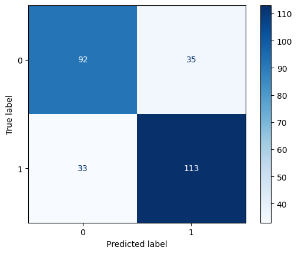

```python
#ChatGPT helped me create the confusion matrix and calculate the precision, recall and true negative rate.
#Fit the final best KNN model
final_knn_pipeline1.fit(X, y)

#Confusion Matrix
#Perform cross-validated predictions
y_pred_cv = cross_val_predict(final_knn_pipeline1, X, y, cv=5)

#Print confusion matrix and classification report
cm = confusion_matrix(y, y_pred_cv)
print(cm)

tn, fp, fn, tp = cm.ravel()

# Metrics
precision = precision_score(y, y_pred_cv)
recall = recall_score(y, y_pred_cv)
true_negative_rate = tn / (tn + fp)

# Print results
print(f"Precision: {precision}")
print(f"Recall: {recall}")
print(f"True Negative Rate: {true_negative_rate}")

disp = ConfusionMatrixDisplay(confusion_matrix=cm, display_labels=np.unique(y))
disp.plot(cmap='Blues')
```

### Logistic Regression

```python
#Logistic Regression on the whole dataset
logreg_pipeline1 = Pipeline(
  [("preprocessing", ct),
  ("logreg", LogisticRegression(max_iter=1000))]
).set_output(transform="pandas")

logreg1 = cross_val_score(logreg_pipeline1, X, y, scoring="roc_auc", cv=5).mean()
print(logreg1)

#Tuning
degrees = {'logreg__C': [0.01, 0.1, 1, 10, 100]}

#Cross Validation
gscv = GridSearchCV(logreg_pipeline1, degrees, cv = 5, scoring='roc_auc')

gscv_fitted = gscv.fit(X, y)

# Get the ROC AUC scores from the grid search results
roc_auc_scores = gscv_fitted.cv_results_['mean_test_score']

# Create DataFrame for results (mean_test_score corresponds to ROC AUC scores)
roc_auc_df = pd.DataFrame(data = {
    "C": degrees['logreg__C'],
    "roc_auc_scores": roc_auc_scores
})

# Output the ROC AUC results
roc_auc_df
```

```
0.8533255526083113
0.8533255526083113
```

|  | C | roc_auc_scores |
| --- | --- | --- |
| 0 | 0.01 | 0.854643 |
| 1 | 0.10 | 0.853325 |
| 2 | 1.00 | 0.853326 |
| 3 | 10.00 | 0.852763 |
| 4 | 100.00 | 0.853028 |

```python
#Log Reg with just cp, sex, age, and thalach

ct2 = ColumnTransformer(
  [
    ("dummify", OneHotEncoder(sparse_output = False, drop="first"), ["cp", "sex"]),
    ("standardize", StandardScaler(), ["age", "thalach"])
  ],
  remainder = "drop"
).set_output(transform="pandas")

logreg_pipeline2 = Pipeline(
  [("preprocessing", ct2),
  ("logreg", LogisticRegression(max_iter=1000))]
).set_output(transform="pandas")

logreg2 = cross_val_score(logreg_pipeline2, X, y, scoring="roc_auc", cv=5).mean()
print(logreg2)

#Tuning
degrees = {'logreg__C': [0.01, 0.1, 1, 10, 100]}

#Cross Validation
gscv = GridSearchCV(logreg_pipeline2, degrees, cv = 5, scoring='roc_auc')

gscv_fitted = gscv.fit(X, y)

# Get the ROC AUC scores from the grid search results
roc_auc_scores = gscv_fitted.cv_results_['mean_test_score']

# Create DataFrame for results (mean_test_score corresponds to ROC AUC scores)
roc_auc_df = pd.DataFrame(data = {
    "C": degrees['logreg__C'],
    "roc_auc_scores": roc_auc_scores
})

# Output the ROC AUC results
roc_auc_df
```

```
0.8585513704686119
0.8585513704686119
```

|  | C | roc_auc_scores |
| --- | --- | --- |
| 0 | 0.01 | 0.795512 |
| 1 | 0.10 | 0.833655 |
| 2 | 1.00 | 0.858551 |
| 3 | 10.00 | 0.860495 |
| 4 | 100.00 | 0.860506 |

```python
#Log Reg with just cp, sex, age, thalach, trtbps, and chol

ct3 = ColumnTransformer(
  [
    ("dummify", OneHotEncoder(sparse_output = False, drop="first"), ["cp", "sex"]),
    ("standardize", StandardScaler(), ["age", "thalach", "trtbps", "chol"])
  ],
  remainder = "drop"
).set_output(transform="pandas")

logreg_pipeline3 = Pipeline(
  [("preprocessing", ct3),
  ("logreg", LogisticRegression(max_iter=1000))]
).set_output(transform="pandas")

logreg3 = cross_val_score(logreg_pipeline3, X, y, scoring="roc_auc", cv=5).mean()
print(logreg3)

#Tuning
degrees = {'logreg__C': [0.01, 0.1, 1, 10, 100]}

#Cross Validation
gscv = GridSearchCV(logreg_pipeline3, degrees, cv = 5, scoring='roc_auc')

gscv_fitted = gscv.fit(X, y)

# Get the ROC AUC scores from the grid search results
roc_auc_scores = gscv_fitted.cv_results_['mean_test_score']

# Create DataFrame for results (mean_test_score corresponds to ROC AUC scores)
roc_auc_df = pd.DataFrame(data = {
    "C": degrees['logreg__C'],
    "roc_auc_scores": roc_auc_scores
})

# Output the ROC AUC results
roc_auc_df
```

```
0.866187798408488
0.866187798408488
```

|  | C | roc_auc_scores |
| --- | --- | --- |
| 0 | 0.01 | 0.791625 |
| 1 | 0.10 | 0.836707 |
| 2 | 1.00 | 0.866188 |
| 3 | 10.00 | 0.871073 |
| 4 | 100.00 | 0.870803 |

```python
final_logreg_pipeline = Pipeline(
  [("preprocessing", ct3),
  ("logreg", LogisticRegression(C=10))]
).set_output(transform="pandas")

logreg5 = cross_val_score(final_logreg_pipeline, X, y, scoring="roc_auc", cv=5).mean()
print(logreg5)
```

```
0.8710733863837312
0.8710733863837312
```

```python
#COEFFICIENTS
# Fit the model
final_logreg_pipeline.fit(X, y)

# Get feature names after preprocessing
preprocessed_feature_names = (
    final_logreg_pipeline.named_steps["preprocessing"]
    .get_feature_names_out(input_features=X.columns)
)

# Get coefficients from Logistic Regression
coefficients = final_logreg_pipeline.named_steps["logreg"].coef_[0]

# Create a DataFrame for coefficients
coefficients_df = pd.DataFrame({
    "Feature": preprocessed_feature_names,
    "Coefficient": coefficients,
    "Absolute Coefficient": abs(coefficients)
}).sort_values(by="Absolute Coefficient", ascending=False)

# Display coefficients
print(coefficients_df)

#Kyle: How do I interpret these coefficients?
#How do I change the coefficients to be absolute values?
```

```
                Feature  Coefficient  Absolute Coefficient
0         dummify__cp_1     2.205018              2.205018
3        dummify__sex_1    -2.167275              2.167275
1         dummify__cp_2     1.996807              1.996807
2         dummify__cp_3     1.828402              1.828402
5  standardize__thalach     0.808054              0.808054
6   standardize__trtbps    -0.360656              0.360656
7     standardize__chol    -0.323270              0.323270
4      standardize__age    -0.244837              0.244837
                Feature  Coefficient  Absolute Coefficient
0         dummify__cp_1     2.205018              2.205018
3        dummify__sex_1    -2.167275              2.167275
1         dummify__cp_2     1.996807              1.996807
2         dummify__cp_3     1.828402              1.828402
5  standardize__thalach     0.808054              0.808054
6   standardize__trtbps    -0.360656              0.360656
7     standardize__chol    -0.323270              0.323270
4      standardize__age    -0.244837              0.244837
```

These coefficients help to understand how each feature in the dataset influences the output variable - whether or not a patient is at risk for a heart attack. With dummify__cp_1 having one of the highest coefficients, suggests that the first category of cp has the strongest positive effect on the output variable. With dummify__sex_1 having the second highest coefficient, suggest that a patients sex has a strong influence on the output variable. In addition the second and third levels of cp also have a strong positive effect on the output variable. The third most significant variable is thalach which also has a positive influence on the output variable.

```
[[ 95  32]
 [ 27 119]]
Precision: 0.7880794701986755
Recall: 0.815068493150685
True Negative Rate: 0.7480314960629921
[[ 95  32]
 [ 27 119]]
Precision: 0.7880794701986755
Recall: 0.815068493150685
True Negative Rate: 0.7480314960629921
```

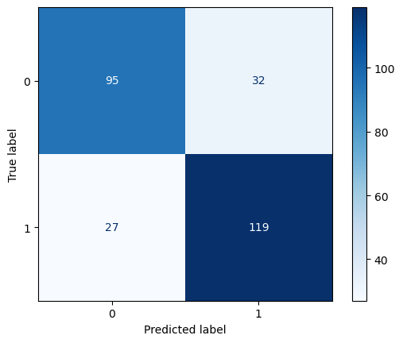

```python
#ChatGPT helped me create the confusion matrix and calculate the precision, recall and true negative rate.
#Fit the final best Log Reg model
final_logreg_pipeline.fit(X, y)

#Confusion Matrix
#Perform cross-validated predictions
y_pred_cv = cross_val_predict(final_logreg_pipeline, X, y, cv=5)

#Print confusion matrix and classification report
cm = confusion_matrix(y, y_pred_cv)
print(cm)

tn, fp, fn, tp = cm.ravel()

# Metrics
precision = precision_score(y, y_pred_cv)
recall = recall_score(y, y_pred_cv)
true_negative_rate = tn / (tn + fp)

# Print results
print(f"Precision: {precision}")
print(f"Recall: {recall}")
print(f"True Negative Rate: {true_negative_rate}")

disp = ConfusionMatrixDisplay(confusion_matrix=cm, display_labels=np.unique(y))
disp.plot(cmap='Blues')
```

For Logistic Regression, I created several different models, one using the entire dataset, a model that only used with cp, sex, age, and thalach, a second model with just cp, sex, age, and thalach, and a third model with just cp, sex, age, thalach, trtbps, and chol. In each of the logistic regression models I created above, I tuned C for values 0.01, 0.1, 1, 10, 100. Based on our Roc Auc scores from all the logistic regression models, the third model which predicted the outcome using cp, sex, age, thalach, trtbps, and chol as variables and used C=10 was the best model with the highest Roc Auc score of 0.871

### Decision Tree

```python
#Decision Tree using the entire dataset

ct = ColumnTransformer(
  [
    ("dummify",
    OneHotEncoder(sparse_output = False, handle_unknown='ignore'),
    make_column_selector(dtype_include=object))
  ],
  remainder = "passthrough"
)

tree_pipeline1 = Pipeline(
  [("preprocessing", ct),
  ("tree", DecisionTreeClassifier(min_samples_leaf=35))]
)
#Kyle: What goes inside the decision tree function? I saw other people puting other things beside max_depth?

#Tuning
degrees = {"tree__min_samples_leaf": [1, 2, 5, 10, 15, 25, 35]}

#Cross Validation
gscv = GridSearchCV(tree_pipeline1, degrees, cv = 5, scoring='roc_auc')

gscv_fitted = gscv.fit(X, y)

# Get the ROC AUC scores from the grid search results
roc_auc_scores = gscv_fitted.cv_results_['mean_test_score']

# Create DataFrame for results (mean_test_score corresponds to ROC AUC scores)
roc_auc_df = pd.DataFrame(data = {
    "min_samples_leaf": degrees['tree__min_samples_leaf'],
    "roc_auc_scores": roc_auc_scores
})

# Output the ROC AUC results
roc_auc_df
```

|  | min_samples_leaf | roc_auc_scores |
| --- | --- | --- |
| 0 | 1 | 0.675287 |
| 1 | 2 | 0.714302 |
| 2 | 5 | 0.770888 |
| 3 | 10 | 0.795843 |
| 4 | 15 | 0.800086 |
| 5 | 25 | 0.814125 |
| 6 | 35 | 0.819434 |

```python
ct1 = ColumnTransformer(
  [
    ("dummify", OneHotEncoder(sparse_output = False, drop="first"), ["cp", "sex"])
  ], remainder = "passthrough"
).set_output(transform="pandas")

ct2 = ColumnTransformer([
    ("interaction1", PolynomialFeatures(interaction_only = True, include_bias=False), ["remainder__age", "dummify__sex_1"]),
    ("interaction2", PolynomialFeatures(interaction_only = True, include_bias=False), ["remainder__age", "dummify__cp_1"]),
    ("interaction3", PolynomialFeatures(interaction_only = True, include_bias=False), ["remainder__thalach", "dummify__sex_1"])]
)

ct3 =  ColumnTransformer([
    ("keep", FunctionTransformer(None), ["interaction1__remainder__age dummify__sex_1", "interaction2__remainder__age dummify__cp_1",
    "interaction1__remainder__age", "interaction3__remainder__thalach", "interaction3__dummify__sex_1", "interaction2__dummify__cp_1",
    'interaction3__remainder__thalach dummify__sex_1'])],
    remainder = "drop"
)

tree_pipeline2 = Pipeline(
  [("preprocessing", ct1),
  ("preprocessing2", ct2),
  ("preprocessing3", ct3),
  ("tree", DecisionTreeClassifier())]
).set_output(transform="pandas")

#Tuning
degrees = {"tree__min_samples_leaf": [1, 2, 5, 10, 15, 25, 35]}

#Cross Validation
gscv = GridSearchCV(tree_pipeline2, degrees, cv = 5, scoring='roc_auc')

gscv_fitted = gscv.fit(X, y)

# Get the ROC AUC scores from the grid search results
roc_auc_scores = gscv_fitted.cv_results_['mean_test_score']

# Create DataFrame for results (mean_test_score corresponds to ROC AUC scores)
roc_auc_df = pd.DataFrame(data = {
    "min_samples_leaf": degrees['tree__min_samples_leaf'],
    "roc_auc_scores": roc_auc_scores
})

# Output the ROC AUC results
roc_auc_df
```

|  | min_samples_leaf | roc_auc_scores |
| --- | --- | --- |
| 0 | 1 | 0.677309 |
| 1 | 2 | 0.698732 |
| 2 | 5 | 0.758157 |
| 3 | 10 | 0.759495 |
| 4 | 15 | 0.768487 |
| 5 | 25 | 0.749459 |
| 6 | 35 | 0.739921 |

```python
#Decision Tree with just cp, sex, age, and thalach

ct1 = ColumnTransformer(
  [
    ("dummify", OneHotEncoder(sparse_output = False, drop="first"), ["cp", "sex"]),
    ("passthrough", FunctionTransformer(), ["age", "thalach"])
  ],
  remainder = "drop"
).set_output(transform="pandas")

tree_pipeline3 = Pipeline(
  [("preprocessing", ct1),
 ("tree", DecisionTreeClassifier())]
).set_output(transform="pandas")

#Tuning
degrees = {"tree__min_samples_leaf": [1, 2, 5, 10, 15, 25, 35]}

#Cross Validation
gscv = GridSearchCV(tree_pipeline3, degrees, cv = 5, scoring='roc_auc')

gscv_fitted = gscv.fit(X, y)

# Get the ROC AUC scores from the grid search results
roc_auc_scores = gscv_fitted.cv_results_['mean_test_score']

# Create DataFrame for results (mean_test_score corresponds to ROC AUC scores)
roc_auc_df = pd.DataFrame(data = {
    "min_samples_leaf": degrees['tree__min_samples_leaf'],
    "roc_auc_scores": roc_auc_scores
})

# Output the ROC AUC results
roc_auc_df
```

|  | min_samples_leaf | roc_auc_scores |
| --- | --- | --- |
| 0 | 1 | 0.688775 |
| 1 | 2 | 0.715806 |
| 2 | 5 | 0.746261 |
| 3 | 10 | 0.769068 |
| 4 | 15 | 0.767682 |
| 5 | 25 | 0.736297 |
| 6 | 35 | 0.722208 |

```python
ct4 = ColumnTransformer(
    [
        ("dummify", OneHotEncoder(sparse_output=False, drop="first"), ["cp", "sex"]),
        ("poly", PolynomialFeatures(degree=2, interaction_only=True, include_bias=False), ["age", "thalach", "chol", "trtbps"])
    ],
    remainder="drop"
).set_output(transform="pandas")

tree_pipeline4 = Pipeline(
  [("preprocessing", ct4),
 ("tree", DecisionTreeClassifier())]
).set_output(transform="pandas")

#Tuning
degrees = {"tree__min_samples_leaf": [1, 2, 5, 10, 15, 25, 35]}

#Cross Validation
gscv = GridSearchCV(tree_pipeline4, degrees, cv = 5, scoring='roc_auc')

gscv_fitted = gscv.fit(X, y)

# Get the ROC AUC scores from the grid search results
roc_auc_scores = gscv_fitted.cv_results_['mean_test_score']

# Create DataFrame for results (mean_test_score corresponds to ROC AUC scores)
roc_auc_df = pd.DataFrame(data = {
    "min_samples_leaf": degrees['tree__min_samples_leaf'],
    "roc_auc_scores": roc_auc_scores
})

# Output the ROC AUC results
roc_auc_df
```

|  | min_samples_leaf | roc_auc_scores |
| --- | --- | --- |
| 0 | 1 | 0.603712 |
| 1 | 2 | 0.637850 |
| 2 | 5 | 0.683185 |
| 3 | 10 | 0.689549 |
| 4 | 15 | 0.745999 |
| 5 | 25 | 0.734388 |
| 6 | 35 | 0.731068 |

```
[[ 94  33]
 [ 34 112]]
Precision: 0.7724137931034483
Recall: 0.7671232876712328
True Negative Rate: 0.7401574803149606
[[ 94  33]
 [ 34 112]]
Precision: 0.7724137931034483
Recall: 0.7671232876712328
True Negative Rate: 0.7401574803149606
```

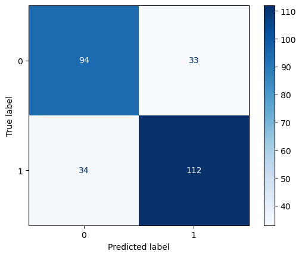

```python
#ChatGPT helped me create the confusion matrix and calculate the precision, recall and true negative rate.

#Fit the final best Decision Tree model
tree_pipeline1.fit(X, y)

#Confusion Matrix
#Perform cross-validated predictions
y_pred_cv = cross_val_predict(tree_pipeline1, X, y, cv=5)

#Print confusion matrix and classification report
cm = confusion_matrix(y, y_pred_cv)
print(cm)

tn, fp, fn, tp = cm.ravel()

# Metrics
precision = precision_score(y, y_pred_cv)
recall = recall_score(y, y_pred_cv)
true_negative_rate = tn / (tn + fp)

# Print results
print(f"Precision: {precision}")
print(f"Recall: {recall}")
print(f"True Negative Rate: {true_negative_rate}")

disp = ConfusionMatrixDisplay(confusion_matrix=cm, display_labels=np.unique(y))
disp.plot(cmap='Blues')
```

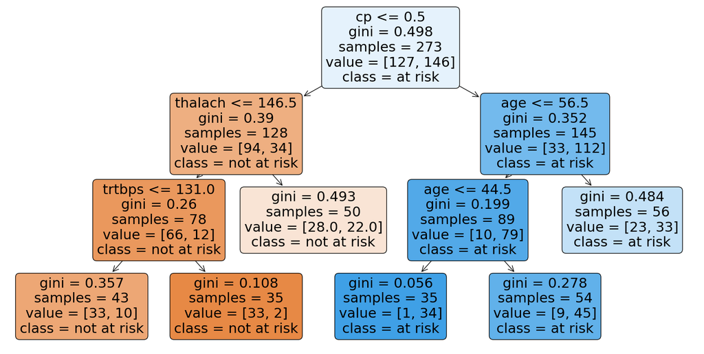

```python
from sklearn.tree import plot_tree
import matplotlib.pyplot as plt
tree_pipeline1.fit(X, y)

#ChatGPT helped me plot the decision tree
# Retrieve the decision tree estimator
decision_tree = tree_pipeline1.named_steps['tree']

# Plot the tree
plt.figure(figsize=(20, 10))
plot_tree(decision_tree, filled=True, feature_names=X.columns, class_names=['not at risk', 'at risk'], rounded=True)
plt.show()
```

### Interpretation

Based on the hihgest coefficients from the logistic regression model and the first few splits of the decision tree model, the most important variables at predicting whether a patient is at risk for a heart attack are a patients chest pain type (cp), their maximum heart rate achieved during exercise, sex, and age.

### ROC Curve

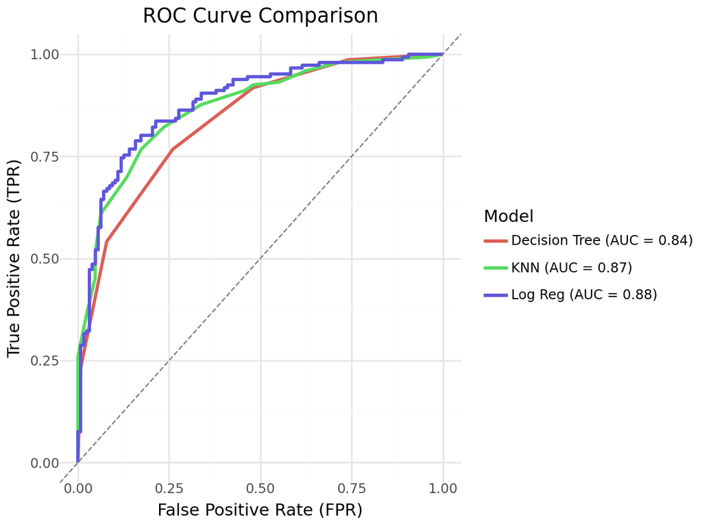

```python
from plotnine import *
#ChatGPT helped me create the ROC Curve

# Fit each model and calculate ROC curve
# Model 1 - KNN
final_knn_pipeline1.fit(X, y)
y_proba_1 = final_knn_pipeline1.predict_proba(X)[:, 1]
fpr_1, tpr_1, _ = roc_curve(y, y_proba_1)
auc_1 = auc(fpr_1, tpr_1)

# Model 2 - Logistic Regression
final_logreg_pipeline.fit(X, y)
y_proba_2 = final_logreg_pipeline.predict_proba(X)[:, 1]
fpr_2, tpr_2, _ = roc_curve(y, y_proba_2)
auc_2 = auc(fpr_2, tpr_2)

# Model 3 - Decision Tree
tree_pipeline1.fit(X, y)
y_proba_3 = tree_pipeline1.predict_proba(X)[:, 1]
fpr_3, tpr_3, _ = roc_curve(y, y_proba_3)
auc_3 = auc(fpr_3, tpr_3)

# Create a DataFrame for plotnine
roc_df = pd.DataFrame({
    "fpr": list(fpr_1) + list(fpr_2) + list(fpr_3),
    "tpr": list(tpr_1) + list(tpr_2) + list(tpr_3),
    "model": (["KNN (AUC = {:.2f})".format(auc_1)] * len(fpr_1)) +
             (["Log Reg (AUC = {:.2f})".format(auc_2)] * len(fpr_2)) +
             (["Decision Tree (AUC = {:.2f})".format(auc_3)] * len(fpr_3))
})

# Plot using plotnine
(
    ggplot(roc_df, aes(x="fpr", y="tpr", color="model")) +
    geom_line(size=1.2) +
    geom_abline(intercept=0, slope=1, linetype="dashed", color="gray") +
    labs(
        title="ROC Curve Comparison",
        x="False Positive Rate (FPR)",
        y="True Positive Rate (TPR)",
        color="Model"
    ) +
    theme_minimal()
)
```

## Part 2: Metrics

**See Calculations Above**

Consider the following metrics:

**True Positive Rate or Recall or Sensitivity**

KNN: 0.774

Logistic Regression: 0.815

Decision Tree: 0.767

**Precision or Positive Predictive Value**

KNN: 0.764

Logistic Regression: 0.788

Decision Tree: 0.772

**True Negative Rate or Specificity or Negative Predictive Value**

KNN: 0.724

Logistic Regression: 0.748

Decision Tree: 0.740

## Part 3: Discussion

**Q1: The hospital faces severe lawsuits if they deem a patient to be low risk, and that patient later experiences a heart attack.**

For this situation, it is crucial to minimize false negatives, as failing to identify high-risk patients could lead to lawsuits. To select the best model, we would prioritize recall, which measures the proportion of actual high-risk patients correctly identified. While precision might also be relevant, recall is the key metric to avoid missing at-risk patients.

The model with the best recall score was the logistic regression model, so I would recommend the hospital use this model for this situation. For this logistic regression model, the hospital should expect a recall score of 0.815, meaning 81.5% of high-risk patients will be correctly identified.

**Q2: The hospital is overfull, and wants to only use bed space for patients most in need of monitoring due to heart attack risk.**

Since the hospital wants to prioritize patients who are truly at risk and avoid wasting bed space on false positives, the primary metric for model selection should be precision, which measures the proportion of patients flagged as high risk who are actually high risk. This approach ensures that admitted patients are indeed the most in need of monitoring.

The model with the highest precision score was the logistic regression model, so I would recommend the hospital use this model for this situation. For this logistic regression model, the hospital should expect a precision score of 0.788, meaning 78.8% of patients flagged as high risk are truly at risk.

**Q3: The hospital is studying root causes of heart attacks, and would like to understand which biological measures are associated with heart attack risk.**

For this situation, I would use ROC AUC as a general performance measure while selecting the decision tree model for its interpretability. The hospital can use this model to understand how biological factors contribute to heart attack risk and uncover valuable insights. The ROC AUC score for the best decision tree model was 0.819.

**Q4: The hospital is training a new batch of doctors, and they would like to compare the diagnoses of these doctors to the predictions given by the algorithm to measure the ability of new doctors to diagnose patients.**

For this situation, it is important to measure the agreement between the algorithm’s predictions and the doctors’ diagnoses. The ideal metric for this scenario is Cohen’s Kappa, as it accounts for agreement beyond random chance, making it appropriate for comparing human performance with the algorithm.

## Part 4: Validation

Use each of your final models in Part One Q1-3, predict the target variable in the validation dataset.

For each, output a confusion matrix, and report the ROC AUC, the precision, and the recall.

Compare these values to the cross-validated estimates you reported in Part One and Part Two. Did our measure of model success turn out to be approximately correct for the validation data? Kyle: What am I looking at here? How do I answer this question?

```python
ha_validation = pd.read_csv("https://www.dropbox.com/s/jkwqdiyx6o6oad0/heart_attack_validation.csv?dl=1")

X_val = ha_validation.drop(columns=["output"])
y_val = ha_validation["output"]
```

```
KNN Results:
Confusion Matrix:
[[10  1]
 [ 6 13]]
ROC AUC: 0.955
Precision: 0.929
Recall: 0.684
KNN Results:
Confusion Matrix:
[[10  1]
 [ 6 13]]
ROC AUC: 0.955
Precision: 0.929
Recall: 0.684
```

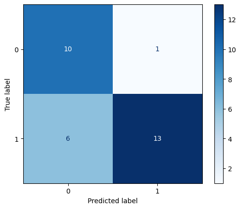

```python
#ChatGPT helped me compute the confusion matrix and report the ROC AUC, precision, and recall.
y_pred_knn = final_knn_pipeline1.predict(X_val)
y_prob_knn = final_knn_pipeline1.predict_proba(X_val)[:, 1]  # Probability estimates for ROC AUC

# Confusion matrix
cm_knn = confusion_matrix(y_val, y_pred_knn)

# Metrics
roc_auc_knn = roc_auc_score(y_val, y_prob_knn)
precision_knn = precision_score(y_val, y_pred_knn)
recall_knn = recall_score(y_val, y_pred_knn)

# Print results
print("KNN Results:")
print(f"Confusion Matrix:\n{cm_knn}")
print(f"ROC AUC: {roc_auc_knn:.3f}")
print(f"Precision: {precision_knn:.3f}")
print(f"Recall: {recall_knn:.3f}")

disp = ConfusionMatrixDisplay(confusion_matrix=cm_knn, display_labels=np.unique(y))
disp.plot(cmap='Blues')
```

```
Log Reg Results:
Confusion Matrix:
[[ 8  3]
 [ 5 14]]
ROC AUC: 0.890
Precision: 0.824
Recall: 0.737
Log Reg Results:
Confusion Matrix:
[[ 8  3]
 [ 5 14]]
ROC AUC: 0.890
Precision: 0.824
Recall: 0.737
```

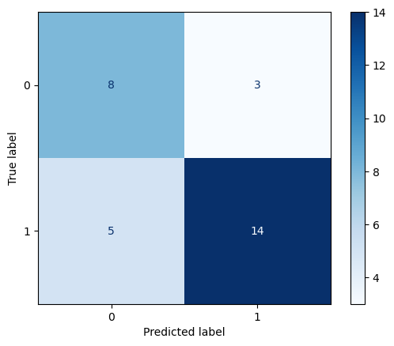

```python
#ChatGPT helped me compute the confusion matrix and report the ROC AUC, precision, and recall.
y_pred_logreg = final_logreg_pipeline.predict(X_val)
y_prob_logreg = final_logreg_pipeline.predict_proba(X_val)[:, 1]  # Probability estimates for ROC AUC

# Confusion matrix
cm_logreg = confusion_matrix(y_val, y_pred_logreg)

# Metrics
roc_auc_logreg = roc_auc_score(y_val, y_prob_logreg)
precision_logreg = precision_score(y_val, y_pred_logreg)
recall_logreg = recall_score(y_val, y_pred_logreg)

# Print results
print("Log Reg Results:")
print(f"Confusion Matrix:\n{cm_logreg}")
print(f"ROC AUC: {roc_auc_logreg:.3f}")
print(f"Precision: {precision_logreg:.3f}")
print(f"Recall: {recall_logreg:.3f}")

disp = ConfusionMatrixDisplay(confusion_matrix=cm_logreg, display_labels=np.unique(y))
disp.plot(cmap='Blues')
```

```
Decision Tree Results:
Confusion Matrix:
[[10  1]
 [ 5 14]]
ROC AUC: 0.900
Precision: 0.933
Recall: 0.737
Decision Tree Results:
Confusion Matrix:
[[10  1]
 [ 5 14]]
ROC AUC: 0.900
Precision: 0.933
Recall: 0.737
```

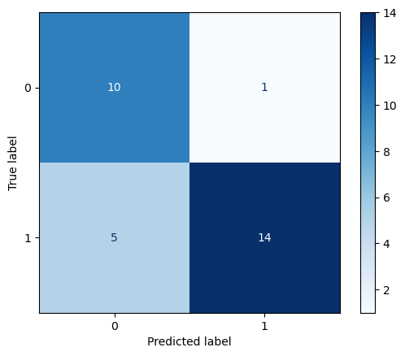

```python
#ChatGPT helped me compute the confusion matrix and report the ROC AUC, precision, and recall.
y_pred_tree = tree_pipeline1.predict(X_val)
y_prob_tree = tree_pipeline1.predict_proba(X_val)[:, 1]  # Probability estimates for ROC AUC

# Confusion matrix
cm_tree = confusion_matrix(y_val, y_pred_tree)

# Metrics
roc_auc_tree = roc_auc_score(y_val, y_prob_tree)
precision_tree = precision_score(y_val, y_pred_tree)
recall_tree = recall_score(y_val, y_pred_tree)

# Print results
print("Decision Tree Results:")
print(f"Confusion Matrix:\n{cm_tree}")
print(f"ROC AUC: {roc_auc_tree:.3f}")
print(f"Precision: {precision_tree:.3f}")
print(f"Recall: {recall_tree:.3f}")

disp = ConfusionMatrixDisplay(confusion_matrix=cm_tree, display_labels=np.unique(y))
disp.plot(cmap='Blues')
```

When comparing the metric scores from cross-validation to those from the validation dataset, most metrics (ROC AUC and precision) significantly increased when applied to the validation set, demonstrating improved model performance. However, recall showed a noticeable decrease. This suggests that while our cross-validated estimates were generally accurate and consistent for ranking model performance, there are some variations when applied to new, unseen data. These differences may be due to random sampling differences between the training and validation datasets or changes in the distribution of the validation set.

## Part 5: Cohen’s Kappa

Cohen’s Kappa measures the agreement between predicted and actual classifications, adjusted for the agreement that could occur by chance. This adjustment makes Cohen’s Kappa a valuable complement to metrics like accuracy, particularly in scenarios involving imbalanced datasets. For example, if one class dominates the dataset, a model could achieve high accuracy simply by overpredicting the majority class. However, Cohen’s Kappa accounts for this imbalance by incorporating the probability of random agreement, providing a clearer and more nuanced view of model performance.

Cohen’s Kappa is especially useful in practical scenarios where balanced performance across classes is crucial. It helps evaluate the quality of predictions in cases where class distribution is uneven, ensuring that success is not inflated due to chance alignment. Additionally, it provides insights into model quality in situations where agreement with human judgment is critical. Cohen’s Kappa is also useful when you want to measure agreement beyond random chance, particularly in classification tasks or when validating models against human performance.

```python
#Cohen's Kappa for KNN
final_knn_pipeline1.fit(X, y)

y_pred = final_knn_pipeline1.predict(X)

# Calculate Cohen's Kappa
kappa = cohen_kappa_score(y, y_pred)
print(f"KNN Cohen's Kappa: {kappa}")
```

```
KNN Cohen's Kappa: 0.5869001297016861
KNN Cohen's Kappa: 0.5869001297016861
```

```python
#Cohen's Kappa for Logistic Regression
final_logreg_pipeline.fit(X, y)

y_pred = final_logreg_pipeline.predict(X)

# Calculate Cohen's Kappa
logreg = cohen_kappa_score(y, y_pred)
print(f"Logistic Regression Cohen's Kappa: {logreg}")
```

```
Logistic Regression Cohen's Kappa: 0.5860500379075056
Logistic Regression Cohen's Kappa: 0.5860500379075056
```

```python
#Cohen's Kappa for Decision Tree
tree_pipeline1.fit(X, y)

y_pred = tree_pipeline1.predict(X)

# Calculate Cohen's Kappa
tree = cohen_kappa_score(y, y_pred)
print(f"Decision Tree Cohen's Kappa: {tree}")
```

```
Decision Tree Cohen's Kappa: 0.5070209956068242
Decision Tree Cohen's Kappa: 0.5070209956068242
```